# Shape-constrained models for functional responses

16 July 2024

## modeling tradeoffs

Levins (1966): modelers face a tradeoff among **realism**, **precision**, and **generality**

- realism and precision  
  [engineering: **tactical** models]
- precision and generality  
  [physics: “spherical cow”, e.g. Lotka-Volterra model]
- realism and generality  
  [math: qualitative models,  
  e.g. “\(f(x)\) is monotonically increasing”]

see also Aday (1978)

## parametric models

- precise, more realistic, less general
- interpretable/testable parameters
- often have to select among many options
- induce specific (implicit) assumptions about curve shape

Quinn et al. (1999)

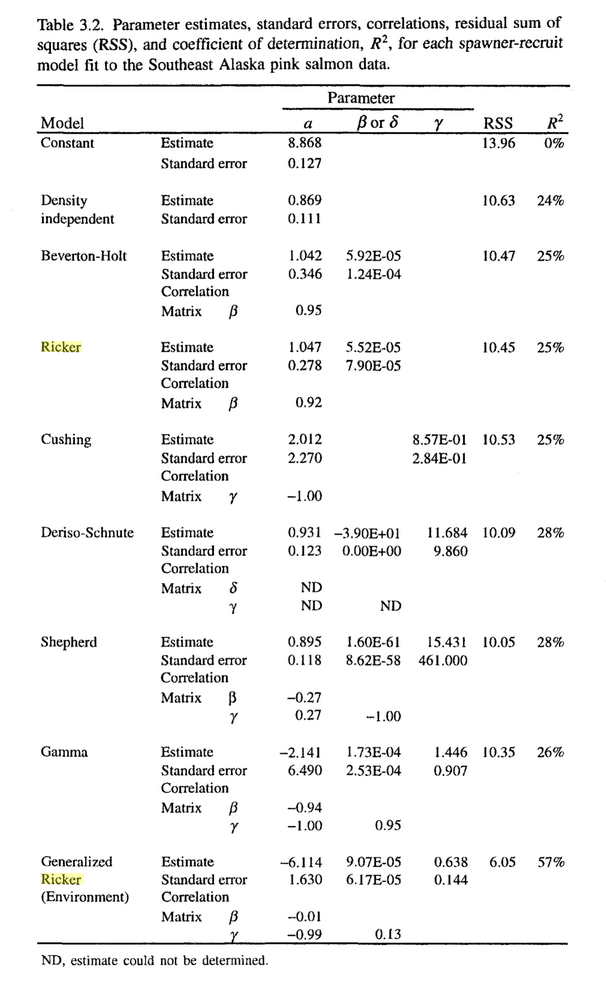

## non/semiparametric models

gain precision without sacrificing realism and generality (?)

- **generalized additive models**
  - increase generality (“\(f(x)\) is a smooth function”)
  - generally *phenomenological*
  - harder to interpret
- **semi-mechanistic models**
  - aka “partially specified”, “semi-parametric”
  - combine known structure with flexible curves
  - Ellner et al. (1998), Wood (2001), Nelson et al. (2004), Thorson et al. (2014)

## shape-constrained models

- more specific/stronger constraints than “\(f(x)\) is smooth”
- e.g. \(f(x)\) is monotonic, unimodal, convex, concave …
- e.g. Ramsay (1998) (monotone), Munch et al. (2005), Andersen et al. (2017), Köllmann et al. (2014)
- but especially Pya et al. (2015)

## shape-constrained bases

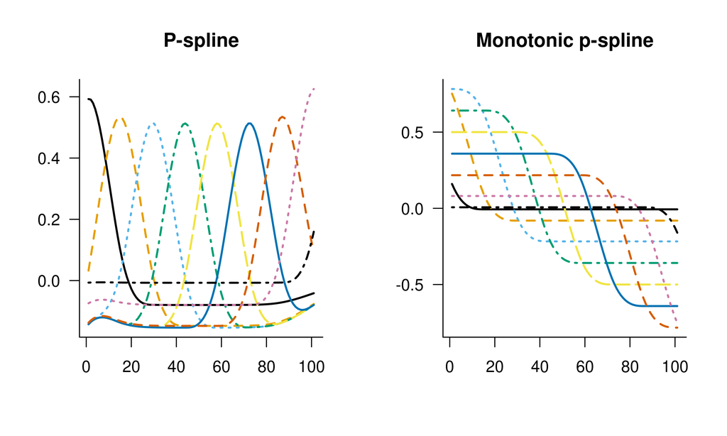

## reed frog predation (Vonesh et al. 2005)

- data + Holling type 2 fit

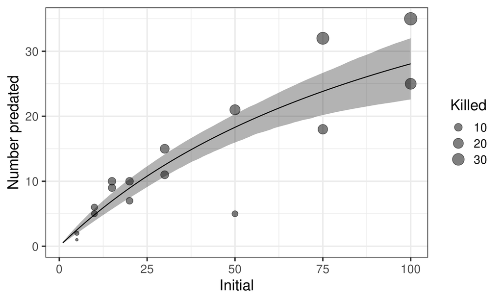

## model fits to *per capita* pred

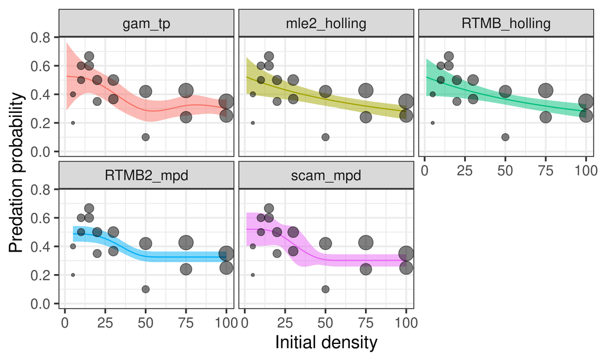

## goodness of fit

| model | ΔAIC | Δnll | df |
| --- | --- | --- | --- |
| scam/mpd | 0.0 | 0.58 | 3.0 |
| gam/tp | 1.7 | 0.00 | 4.4 |
| mle2/holling | 2.9 | 3.02 | 2.0 |

## size/density interactions

- McCoy et al. (2011):  
  dragonfly nymphs vs. red-eyed treefrog tadpoles

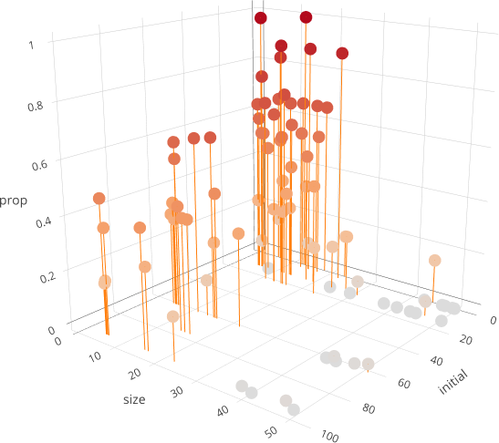

## mechanistic fit

predation prob = \(a(s)/(1+a(s) h(s) x)\)  
\(a(s)\) = Ricker, \(h(s) = cs\)

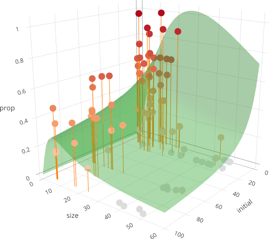

## GAM fit

`mgcv::gam()`  
with `s(size, initial, bs = "te")`

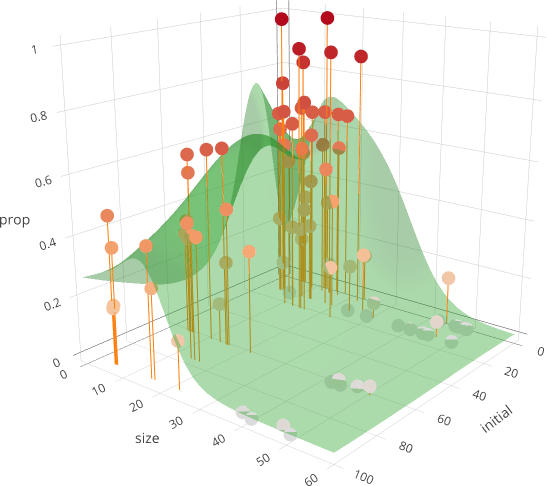

## shape-constrained fit

`scam::scam()`  
with `bs = "tedecv"` (decreasing × concave)

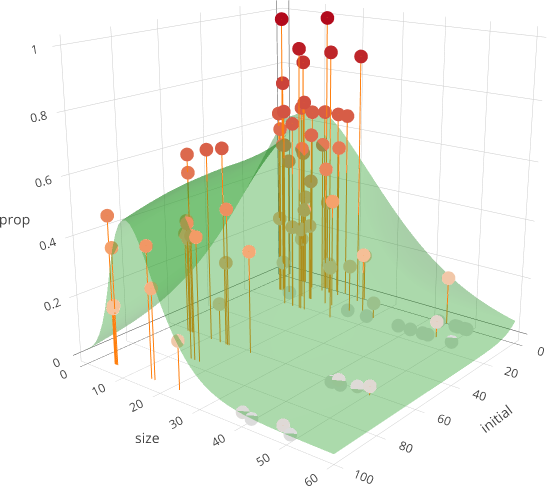

## shape-constrained fit (RTMB)

`RTMB`  
same basis/penalty as `scam`

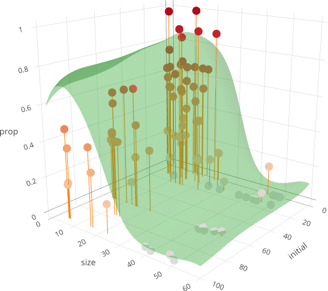

## goodness of fit

| model | ΔAIC | Δnll | df |
| --- | --- | --- | --- |
| gam/te | 0.0 | 0.0 | 15.6 |
| scam/tedecv | 7.5 | 11.7 | 7.7 |
| mle2/rickerprop | 451.4 | 238.3 | 3.0 |

## conclusions

- Acknowledgements
  - “shoulders of giants” (Wood [`mgcv`], Pya [`scam`], Kristensen [`RTMB`])
  - data providers (Mike McCoy, James Vonesh)
  - $$ (NSERC Discovery)
- Source: https://github.com/bbolker/isec2024
- Future goals
  - shape-constrained smooths as ‘plug and play’ components of more complex models
  - fix `scam` bugs/robustify `RTMB` fitting
  - more constraint options (e.g. unimodal functions)
  - hypothesis testing …

## references

Aday, ML. 1978. *Two out of three ain’t bad*.

Andersen, MR et al. 2017. In *BayesOpt: NIPS Workshop on Bayesian Optimization*. Long Beach, USA. https://bayesopt.github.io/papers/2017/9.pdf.

Ellner, SP et al. 1998. *American Naturalist* 15 (5): 425–440. http://www.webofscience.com/wos/alldb/full-record/BCI:BCI199800254612.

Köllmann, C et al. 2014. *Biometrics* 70 (4): 783–793. doi:10.1111/biom.12193. https://onlinelibrary.wiley.com/doi/abs/10.1111/biom.12193.

Levins, R. 1966. *American Scientist* 54: 421–431. https://www.jstor.org/stable/27836590.

McCoy, MW et al. 2011. *American Naturalist* 177 (6): 752–766. doi:10.1086/659950.

Munch, SB et al. 2005. *Can. J. Fisheries Aquat. Sci.* 62 (8) (August): 1808–1821. doi:10.1139/f05-073.

Nelson, WA et al. 2004. *Ecology* 85 (4): 889–903. doi:10.1890/02-8019.

Pya, N et al. 2015. *Statistics and Computing* 25 (3) (May): 543–559. doi:10.1007/s11222-013-9448-7. https://doi.org/10.1007/s11222-013-9448-7.

Quinn, TJ et al. 1999. *Quantitative Fish Dynamics*. New York: Oxford University Press.

Ramsay, JO. 1998. *J. Roy. Statistical Soc. B* 60 (2): 365–375. doi:10.1111/1467-9868.00130.

Thorson, JT et al. 2014. *Ecology* 95 (2): 329–341. doi:10.1890/13-0187.1.

Vonesh, JR et al. 2005. *Ecology* 86 (6): 1580–1591.

Wood, SN. 2001. *Ecological Monographs* 71 (1): 1–25. doi:10.1890/0012-9615(2001)071[0001:PSEM]2.0.CO;2. https://onlinelibrary.wiley.com/doi/abs/10.1890/0012-9615%282001%29071%5B0001%3APSEM%5D2.0.CO%3B2.